# Regression Diagnostics

John Mayberry

January 24, 2025

## Introduction

In these notes, we are going to discuss some of the potential errors[^1] one might encounter when fitting an SLM to data. We’ll focus on two: nonlinearity and outliers. Section 3.3 of the book has a more detailed coverage and we’ll return to some of the additional issues there at the end of Module 2.

Before we begin, please load and refit the TV and radio models for sales from the last group work.

```r
Advertising =read.csv("../Datasets/Advertising.csv")
sales_lmTV=lm(sales~TV,data=Advertising)
sales_lmR=lm(sales~radio,data=Advertising)
```

## Reducible vs Irreducible Errors

Suppose we have just fit a model of the form
$$Y = f(X) + \varepsilon$$
to data $(x_i,y_i)$ and are at the stage where we have validated that the resulting predictions
$$\hat{y}_i = \hat{f}(x_i)$$
are close to the $y_i$ (for example, by looking at $R^2$), but the model isn’t perfect and we think we could do better. Time to look at the individual errors made by our model. Since
$$y_i - \hat{y} = f(x_i) + \varepsilon_i - \hat{f}(x_i) = f(x_i) -
\hat{f}(x_i)+ \varepsilon_i$$
where $\varepsilon_i$ is the contribution of the noise to the $i$th data point, there are thus two sources of errors to consider

1. Reducible error: Error introduced by the difference between $f$ and $\hat{f}$ (approximation error)
2. Irreducible error: Error resulting from the noise

There is little one can do about irreducible error, other than estimating its variance and incorporating this uncertainty into confidence intervals and prediction intervals. Reducible error, however, can be minimized through the following approaches:

1. **Optimizing Model Parameters**:  
   Use maths to find the best-fitting parameters for a chosen model. For example, in a simple linear model (SLM), this involves minimizing the residual sum of squares to estimate $\beta_0$ and $\beta_1$ using least squares.
2. **Selecting an Appropriate Model Form**:  
   Choose a functional form for $f(x)$ that closely matches the underlying relationship in the data. For instance, we only want to use a linear model if the trend is linear.
3. **Ensuring Data Quality**:  
   Minimize errors in the data itself by addressing issues such as measurement error, outliers, or missing values.

Point 1 isn’t an issue for SLM since we know how to find the best slope and intercept if the relationships actually is linear, but in these notes we’ll look at some things you have to be careful of in 2 and 3.

## Identifying Nonlinearity

**Residuals** are defined as the individual errors
$$e_i = y_i- \hat{y}_i$$
They represent “what’s left over” after accounting for the trend you think you have identified. Most techniques for identifying issues with SLM or other regression models (a broad topic referred to as regression diagnostics) involve looking at the distribution of residuals to identify problems.

If the relationship between $y$ and $x$ truly is linear and we plot the residuals $e_i = y_i - \hat{y}_i$ against $x_i$ or the predicted values $\hat{y}_i$, then there should be no systematic pattern in how the residuals depend on $x$. If there is, it may be evidence of a nonlinear relationship.

To see why, suppose that I generate some fake data according to a quadratic model

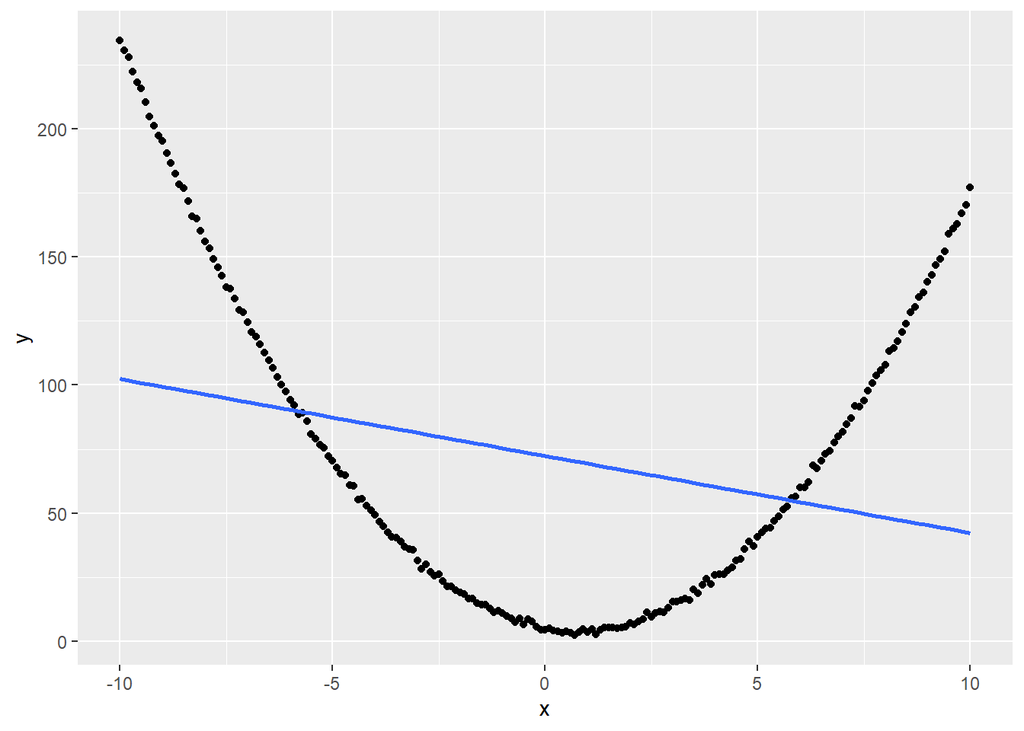

```r
set.seed(123)
x=seq(-10,10,by=0.1)
y=2*x^2-3*x+5+rnorm(length(x))
df=data.frame(x=x,y=y)
df %>% ggplot(aes(x=x,y=y))+geom_point()+
  geom_smooth(method="lm",se=FALSE)
```

Notice how there is a pattern to where we over and under estimate $y$: when $\hat{y}$ is small or large, we underestimate and when $\hat{y}$ is in the middle, we overestimate. If calculate and plot the residuals vs fitted values, we will see this pattern show up as a giant “U”:

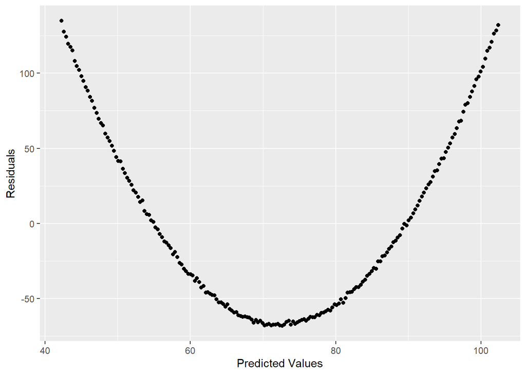

```r
fake_lm=lm(y~x,data=df)
df %>%
  mutate(yhat=predict(fake_lm,df),res=y-yhat) %>%
  ggplot(aes(x=yhat,y=res))+geom_point()+
  labs(x="Predicted Values",y="Residuals")
```

In contrast, if the data actually is linear, we’ll see a random scattering of errors

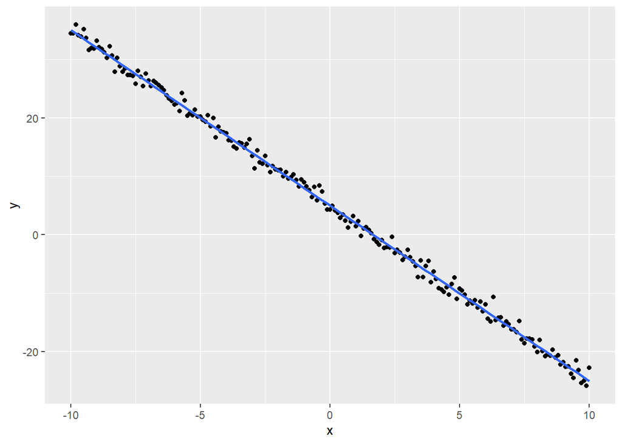

```r
set.seed(123)
x=seq(-10,10,by=0.1)
y=-3*x+5+rnorm(length(x))
df=data.frame(x=x,y=y)
df %>% ggplot(aes(x=x,y=y))+geom_point()+
  geom_smooth(method="lm",se=FALSE)
```

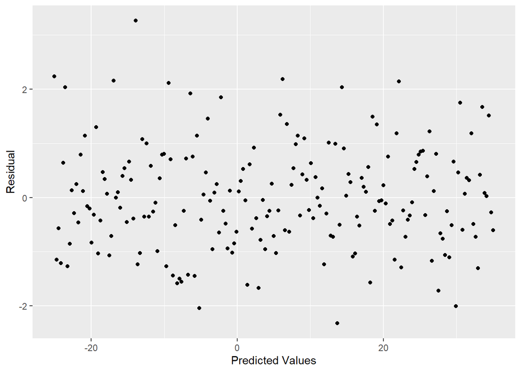

```r
fake_lm=lm(y~x,data=df)
df %>%
  mutate(yhat=predict(fake_lm,df),res=y-yhat) %>%
  ggplot(aes(x=yhat,y=res))+geom_point()+
  labs(x="Predicted Values",y="Residual")
```

Now that we’ve looked at this for fake data, let’s return to our Advertising dataset. We can compute the predicted sales like we’ve been doing by defining a new variable yhat, but if you want to create plots with ggplot, it is helpful to add them to our dataframe as new “engineered” variables using the mutate function from tidyverse

```r
Advertising = Advertising %>% mutate(yhat_TV=predict(sales_lmTV,Advertising),
 yhat_radio=predict(sales_lmR,Advertising),
 res_TV=sales-yhat_TV,
 res_radio=sales-yhat_radio)
head(Advertising)
```

```
##      TV radio newspaper sales   yhat_TV yhat_radio     res_TV   res_radio
## 1 230.1  37.8      69.2  22.1 17.970775   16.96598  4.1292255   5.1340213
## 2  44.5  39.3      45.1  10.4  9.147974   17.26972  1.2520260  -6.8697224
## 3  17.2  45.9      69.3   9.3  7.850224   18.60619  1.4497762  -9.3061946
## 4 151.5  41.3      58.5  18.5 14.234395   17.67471  4.2656054   0.8252861
## 5 180.8  10.8      58.4  12.9 15.627218   11.49859 -2.7272181   1.4014074
## 6   8.7  48.9      75.0   7.2  7.446162   19.21368 -0.2461623 -12.0136819
```

Then we can make residuals plots

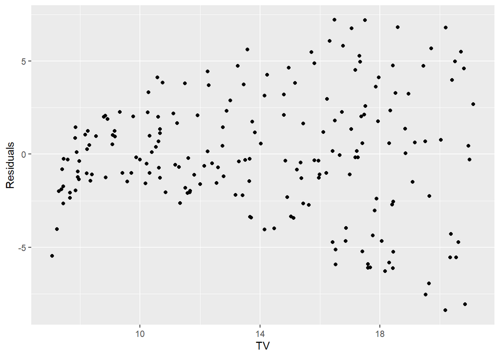

```r
ggplot(Advertising,aes(x=yhat_TV,y=res_TV))+geom_point()+xlab("TV")+ylab("Residuals")
```

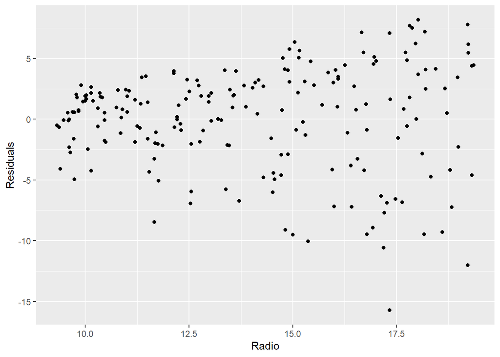

```r
ggplot(Advertising,aes(x=yhat_radio,y=res_radio))+geom_point()+xlab("Radio")+ylab("Residuals")
```

Notice that the residual plot for TV has a bit of an upside down U shape, which could suggest non-linearity, while the radio one has more symmetry in how the points are scattered around 0 (which is good). Both have a slight funnel or bullhorn shape which could be indicative of something called heteroscedasticity (non-constant variances). If we have time, maybe we’ll talk about weighted least squares at some point, but although heteroscedasticity is a cool word, its not as critical as nonlinearity for prediction purposes.

If you see these types of patterns in your data, you might want to consider some kind of log-transform or quadratic model. Since both sales and TV take on only positive values and values range over several orders of magnitude:

```r
summary(Advertising$TV)
```

```
##    Min. 1st Qu.  Median    Mean 3rd Qu.    Max.
##    0.70   74.38  149.75  147.04  218.82  296.40
```

A log-transform might be a good choice. Visually, the data looks more linear on a log-scale:

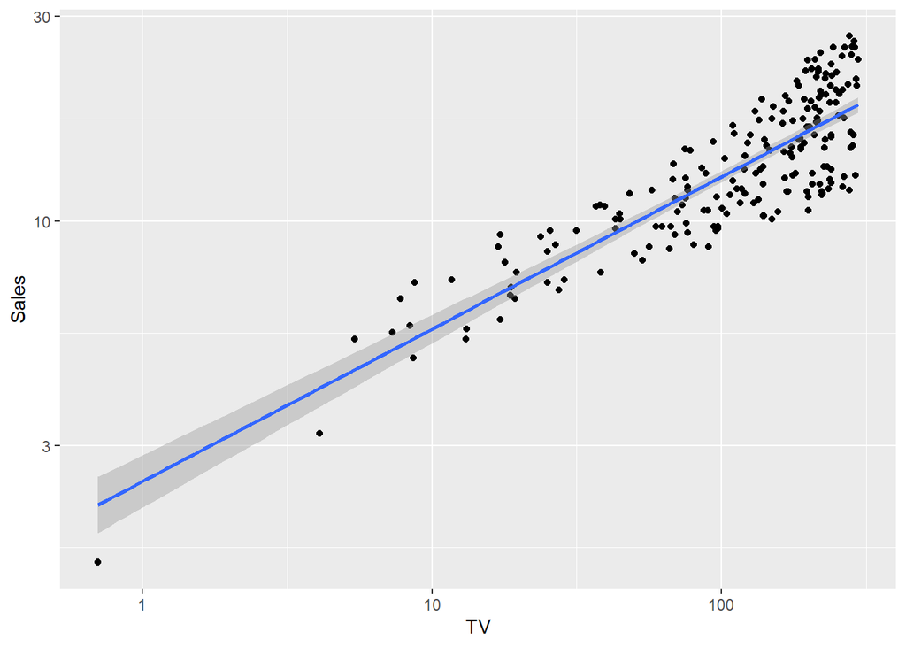

```r
ggplot(Advertising,aes(x=TV,y=sales))+geom_point()+xlab("TV")+ylab("Sales")+scale_x_log10()+scale_y_log10()+geom_smooth(method="lm")
```

Let’s try fitting a new model to the log transformed data

```r
logsales_lmTV=lm(log(sales)~log(TV),data=Advertising)
summary(logsales_lmTV)
```

```
##
## Call:
## lm(formula = log(sales) ~ log(TV), data = Advertising)
##
## Residuals:
##      Min       1Q   Median       3Q      Max
## -0.43349 -0.15917  0.01696  0.16910  0.39399
##
## Coefficients:
##             Estimate Std. Error t value Pr(>|t|)
## (Intercept)  0.90525    0.07107   12.74   <2e-16 ***
## log(TV)      0.35504    0.01487   23.87   <2e-16 ***
## ---
## Signif. codes:  0 '***' 0.001 '**' 0.01 '*' 0.05 '.' 0.1 ' ' 1
##
## Residual standard error: 0.2109 on 198 degrees of freedom
## Multiple R-squared:  0.7421, Adjusted R-squared:  0.7408
## F-statistic: 569.8 on 1 and 198 DF,  p-value: < 2.2e-16
```

That seems promising, with an increase in $R^2$ as well. To view what this fit means for the original data, note that if
$$\log y = a + b \log x$$
then
$$y = e^a x^b$$
We can use the stat function option within ggplot2 to visualize this relationship

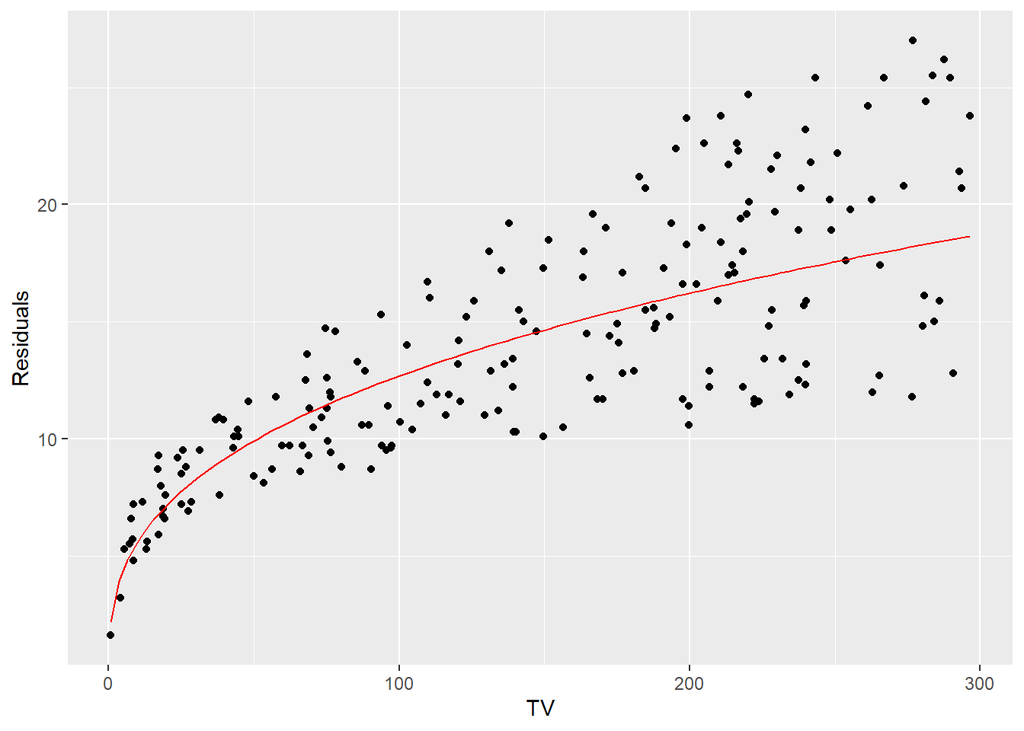

```r
a= coef(logsales_lmTV)[1]
b=coef(logsales_lmTV)[2]
ggplot(Advertising,aes(x=TV,y=sales))+geom_point()+xlab("TV")+ylab("Residuals")+ stat_function(color="red",fun=function(x) exp(a)*x^b)
```

That seems to make a lot more sense! Here is what the residual plot looks like as well (note: here we use transformed values)

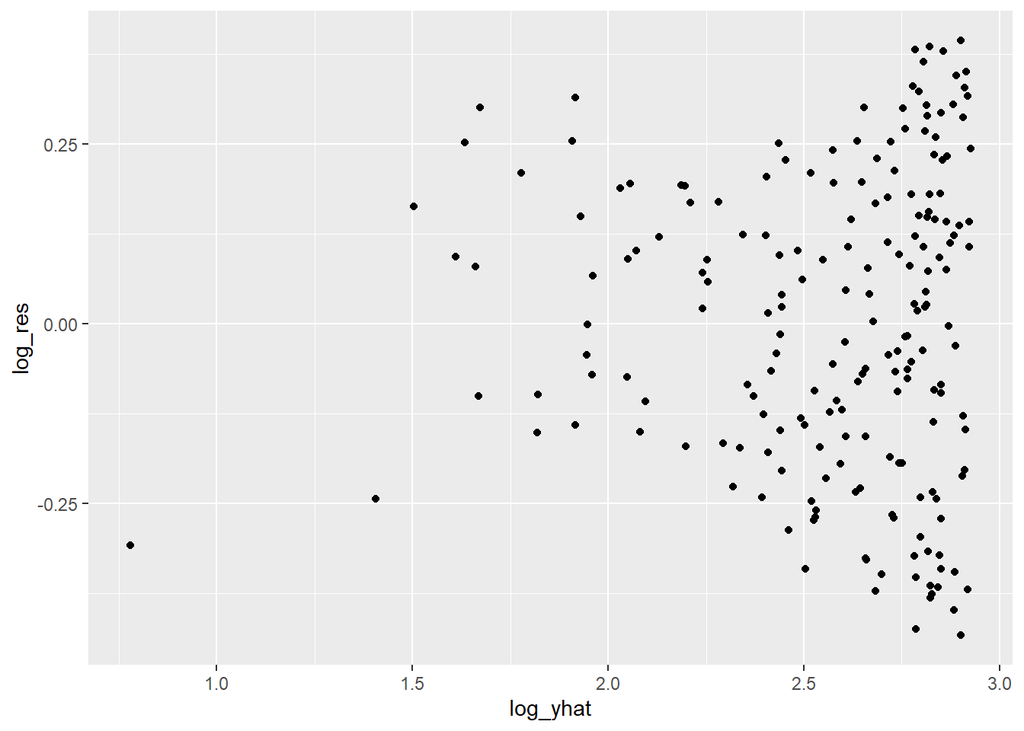

```r
Advertising=Advertising %>% mutate(log_sales=log(sales),
             log_yhat=predict(logsales_lmTV,Advertising),
             log_res=log_sales-log_yhat)
ggplot(Advertising,aes(x=log_yhat,y=log_res))+geom_point()
```

This plot definitely has less of a U-shape and funnel even though it still isn’t perfect.

## Outliers

The third issue mentioned earlier is quality of data. While you do not often have control over the data you receive as statisticians (unless you are fortunate enough to be involved in the data collection process), you can still identify unusual points or points that have a larger than usual influence on the SLM fit. The former are called outliers and the latter, high leverage points.

Both outliers and high-leverage points can have dramatic effects on your model accuracy, but we are only going to talk about the former here because I am getting tired. There are not hard and fast rules for identifying or dealing with outliers, but they are always worth considering and I’ll give you some advice below.

Outliers are points with unusually high residuals. They are very punk rock and don’t conform to the standards. Sometimes you can pick them out immediately by plotting the data, but another common method is to look at the distribution of standardized (sometimes called studentized) residuals.

Standardized residuals are the regular residuals converted to z-scores. Assuming we have already ruled out bias due to nonlinearity, thee residuals should have mean 0 so we can covert to z-scores if we divide by their standard deviation. The common method for estimated the standard deviation of residuals is called the Residual Standard Error (RSE):
$$RSE = \sqrt{SSE/(n-2)}$$
Its basically the RMSE, but we divide by $n-2$ because of the “degrees of freedom[^2]”

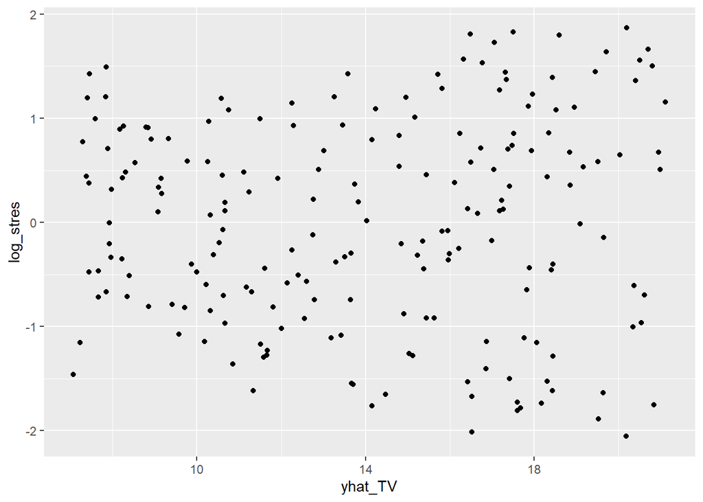

```r
n=nrow(Advertising)
rse=sqrt(sum((Advertising$log_res)^2)/(n-2))
Advertising=Advertising %>%
  mutate(log_stres=log_res/rse)
ggplot(Advertising,aes(x=yhat_TV,y=log_stres))+
  geom_point()
```

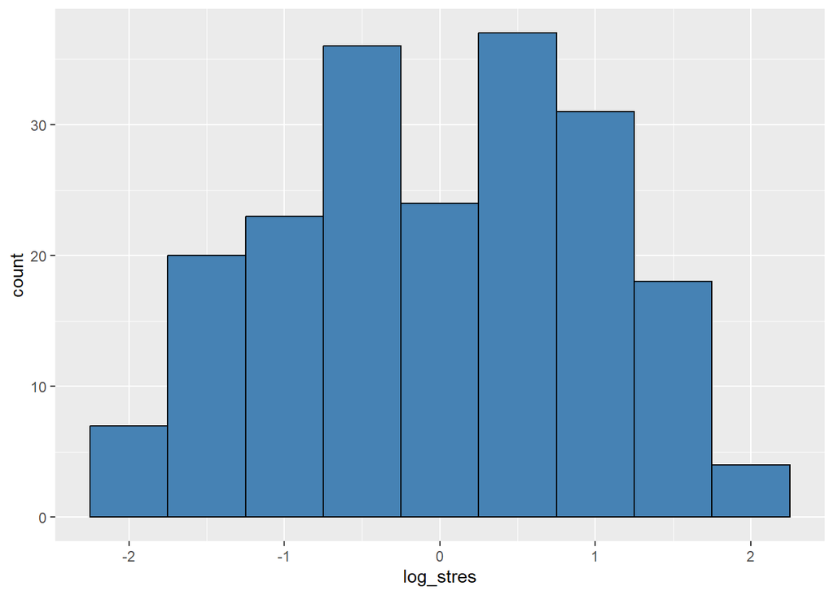

```r
ggplot(Advertising,aes(x=log_stres))+geom_histogram(binwidth=0.5,color="black",fill="steelblue")
```

These two plots reveal that (1) the distribution of standardized residuals is pretty symmetric and reasonably approximated by a standard normal distribution and (2) there may be a couple of outliers in the lower end of the distribution (points with standardized residuals close to -2). Let’s look at those observations in the lowest bin:

```r
Advertising[which(Advertising$log_stres<(-2)),]
```

```
##        TV radio newspaper sales  yhat_TV yhat_radio    res_TV res_radio
## 10  199.8   2.6      21.2  10.6 16.53041   9.838127 -5.930414 0.7618729
## 179 276.7   2.3      23.7  11.8 20.18598   9.777378 -8.385982 2.0226216
##     log_sales log_yhat    log_res log_stres
## 10   2.360854 2.785982 -0.4251282 -2.015407
## 179  2.468100 2.901588 -0.4334884 -2.055040
```

Our model over-predicted both (“outliers” colored in red):

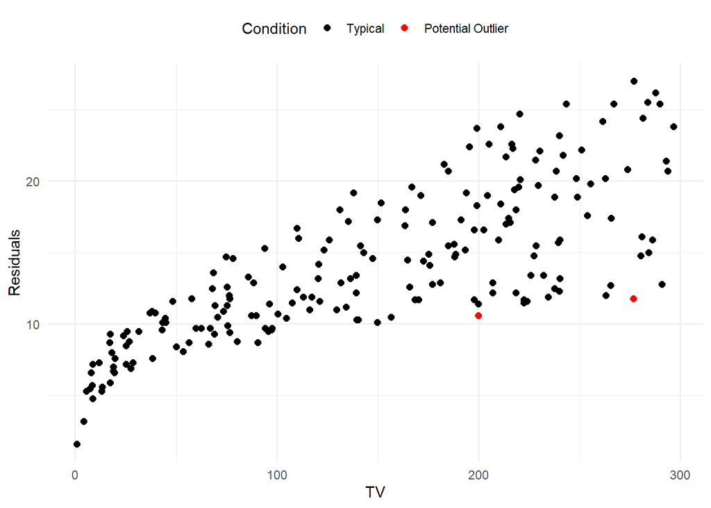

```r
ggplot(Advertising, aes(x = TV, y = sales)) +
  geom_point(aes(color = log_stres < -2), size = 2) +  # Highlight points based on condition
  scale_color_manual(
    values = c("black", "red"),
    labels = c("Typical", "Potential Outlier"),
    name = "Condition"
  ) +
  xlab("TV") +
  ylab("Residuals") +
  theme_minimal() +
  theme(legend.position = "top")  # Move legend to the top for clarity
```

We have two choices about what to do with these outliers:

1. Take them out and refit: best choice if the company identifies these as experimental situations that will not be reproduced in the future
2. Leave them in and keep model as is: best choice if the company identifies them as typical strategies.

In this case, excluding the two points does lead to a slight increase in R^2:

```r
logsales_lmTV2=lm(log(sales)~log(TV),data=dplyr::filter(Advertising,log_stres>=-2))
summary(logsales_lmTV2)
```

```
##
## Call:
## lm(formula = log(sales) ~ log(TV), data = dplyr::filter(Advertising,
##     log_stres >= -2))
##
## Residuals:
##      Min       1Q   Median       3Q      Max
## -0.40596 -0.15981  0.01476  0.16923  0.38637
##
## Coefficients:
##             Estimate Std. Error t value Pr(>|t|)
## (Intercept)  0.89360    0.07001   12.76   <2e-16 ***
## log(TV)      0.35846    0.01467   24.43   <2e-16 ***
## ---
## Signif. codes:  0 '***' 0.001 '**' 0.01 '*' 0.05 '.' 0.1 ' ' 1
##
## Residual standard error: 0.2075 on 196 degrees of freedom
## Multiple R-squared:  0.7527, Adjusted R-squared:  0.7515
## F-statistic: 596.7 on 1 and 196 DF,  p-value: < 2.2e-16
```

but again, I think letting the application guide you is the best principle for outliers.

## Next up…

Looking carefully at the outliers from the previous section, one might also notice that they both had smaller values of radio:

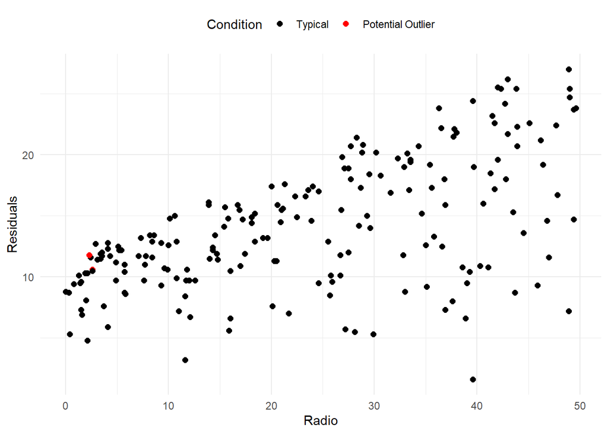

```r
ggplot(Advertising, aes(x = radio, y = sales)) +
  geom_point(aes(color = log_stres < -2), size = 2) +  # Highlight points based on condition
  scale_color_manual(
    values = c("black", "red"),
    labels = c("Typical", "Potential Outlier"),
    name = "Condition"
  ) +
  xlab("Radio") +
  ylab("Residuals") +
  theme_minimal() +
  theme(legend.position = "top")  # Move legend to the top for clarity
```

This may suggest that incorporating both radio and TV in a model will provide us with a better fit than models just based on one of the two predictors. Next week, we’ll discuss multiple regression model which can have as many features as your heart desires. Until then, fuck off.

[^1]: In terms of model fitting, not coding. You’re on your own with the latter.
[^2]: Ugh, too many asides. I envy authors of fantasy epics who will just throw out mystery terms and not explain them until four books and 5000 pages later. Basically, degrees of freedom is the sample size minus the number of parameters estimated from the data. For SLM, that’s two (slope and intercept).